# Numerical evaluation of Tweedie probability functions

## Example: the data

- Total July rainfall at Quilpie:

```
  Year Rain   SOI   Phase
1 1921 38.4   2.7     2
2 1922  0.0   2.0     5
3 1923  0.0 -10.7     3
4 1924 24.4   6.9     2
5 1925  0.0 -12.5     3
6 1926  9.1  -1.0     4
```

- $n = 68$ July totals.
- Monthly rainfall is a positive continuous quantity when it falls, or exactly zero when there is no rain.
- Exactly zero rainfall recorded for 20 months (29%).

[figure not shown]

## Example: Quilpie rainfall

- The model is
  $$\begin{cases}
  Y_i \sim \text{Tweedie}(\mu_i; \xi) & \text{(random component)}\\
  \log \mu_i = \mathbf{X}\vec{\beta} & \text{(systematic component)}
  \end{cases}$$
- **Randomness**: mixed data, so use a **Poisson–gamma** probability model.
- **Systematic**: use *log-link function*:
  - Ensures predicted means $\hat{\mu}_i > 0$.
  - Appropriate for the data.
  - The effect of the covariates $x_j$ on $\mu$ is *multiplicative* not *additive*.
  - As a covariate: use the SOI.

## Example: process

The fitting **process** is like fitting other GLMs, with some idiosyncrasies.

1. Determine *which* Tweedie distribution is appropriate (i.e., the value of $\xi$).
2. Fit the GLM.
3. Evaluate the model; examine diagnostics (using **quantile residuals**).
   - Usual Wald tests ($t$-tests) and likelihood ratio tests ($F$-tests) can be used.
   - AIC needs full likelihood calculations.

[figure not shown]

## Example: find the value of $\xi$

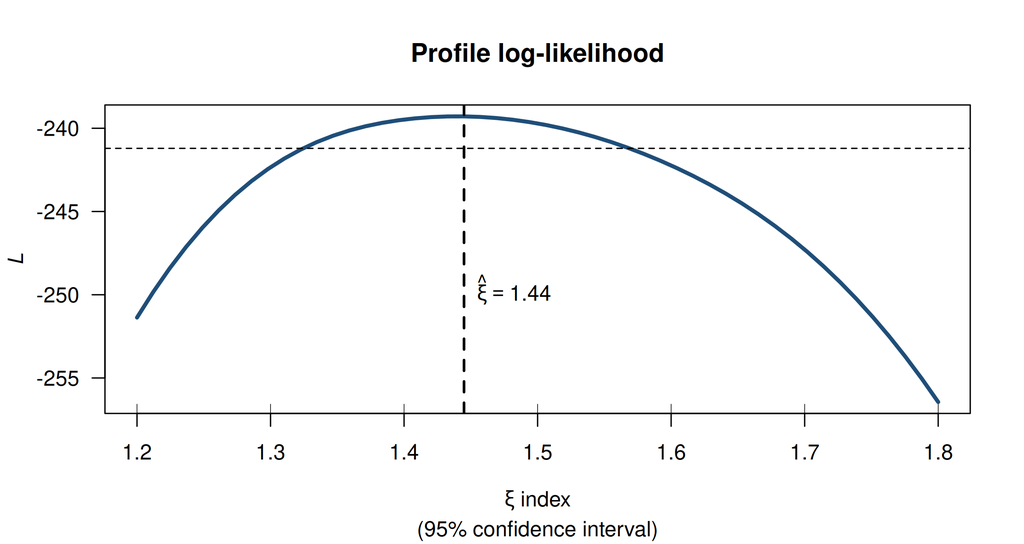

## Example: the model

$$\begin{cases}
Y_i \sim \text{Tweedie}(\mu_i; \xi = 1.44) & \text{(random)}\\
\log \mu_i = 2.61 + (0.073\times\text{SOI}) & \text{(systematic)}
\end{cases}$$

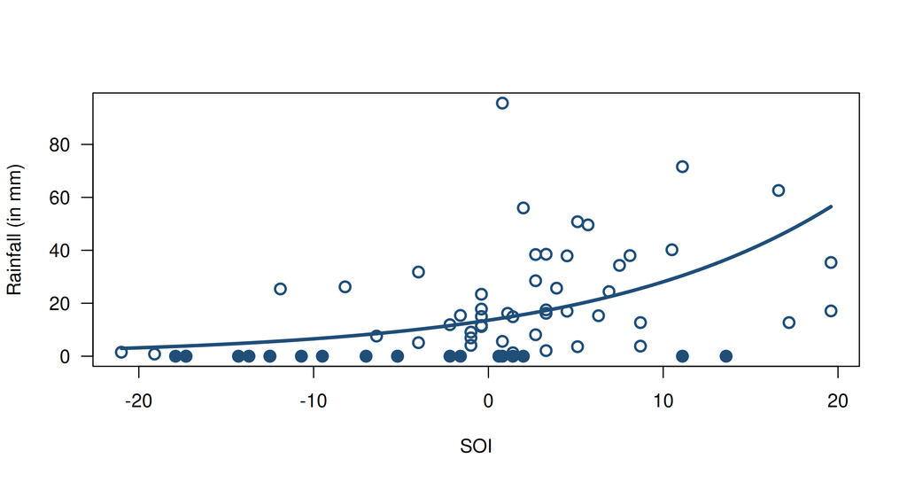

## Example: model evaluation

| Variable | Coefficients | Standard error | $t$-score | $P$-value |
| --- | --- | --- | --- | --- |
| Intercept | 2.61 | 0.152 | 17.1 | < 0.001 |
| SOI | 0.073 | 0.0165 | 4.42 | < 0.001 |

| Model | Deviance | DF | Resid deviance | $F$-score | $P$-value |
| --- | --- | --- | --- | --- | --- |
| Intercept only |  | 67 | 617.44 |  |  |
| + SOI | 120.63 | 66 | 496.81 | 17.09 | < 0.001 |

## Example: diagnostic analysis

Using quantile residuals (Dunn and Smyth (1996)):

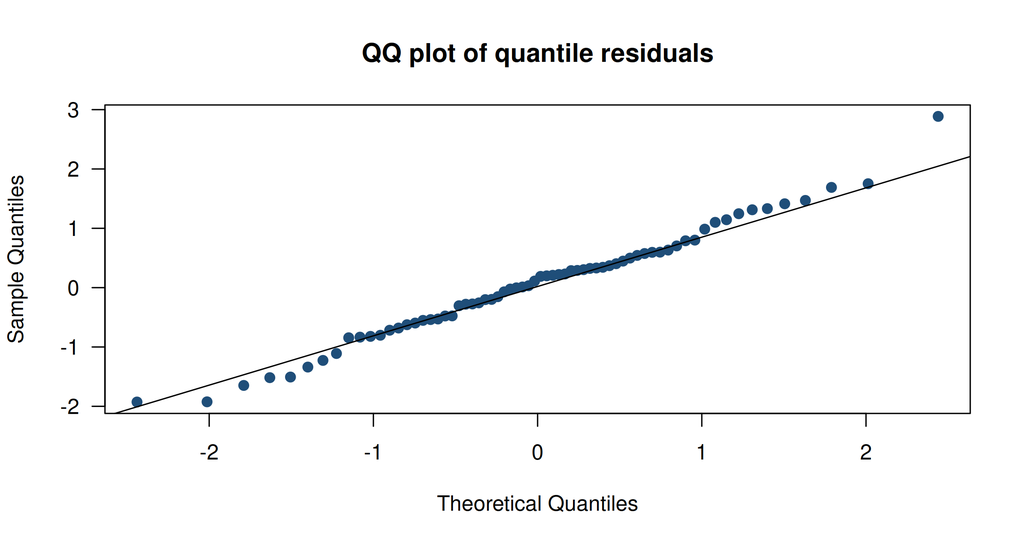

# Concluding

## Accuracy

- No closed form exists (in general) for the PDF or DF.
- So no ‘gold standard’ exists for **checking the accuracy and precision** of the algorithms.
- We can use arbitrary-precision arithmetic to get very precise values.
- But, the algorithms:
  - give accurate results for the closed-form cases ($\xi = 2$ and $\xi = 3$);
  - convergence occurs to machine accuracy where possible;
  - give sensible answers;
  - produce similar answers when using different methods.

[figure not shown]

## Packaging

Algorithms prepared and packaged for use in the `tweedie` package (Dunn 2026).

- Freely available on CRAN.
- Coded in R and FORTRAN.
- **Over 1 million downloads**.

[figure not shown]

## The future

Interpolation method:

- We also have a faster method, using accurate interpolation of stored precise values (yet to be published).
- Much faster, but loses some accuracy in some limiting cases.

Parts of the parameters space (i.e., $(y, \xi, \mu, \phi)$ combinations) are still challenging for accurate evaluation.

- Other evaluation method are possible, which may work well and/or faster in parts of parameter space.
- We have plans for exploring these…

[figure not shown]

## Details

This talk is available at `https://github.com/PeterKDunn/2026-QANZIAM/tree/main`

[figure not shown]

## References

Aalen, Odd O. 1992. “Modelling Heterogeneity in Survival Analysis by the Compound Poisson Distribution.” *The Annals of Applied Probability* 2 (4): 951–72.

Candy, S. G. 2004. “Modelling Catch and Effort Data Using Generalized Linear Models, the Tweedie Distribution, Random Vessel Effects and Random Stratum-by-Year Effects.” *CCAMLR Science* 11: 59–80.

Daniels, H. E. 1954. “Saddlepoint Approximations in Statistics.” *Annals of Mathematical Statistics* 25 (4): 631–50.

Dunn, Peter K. 2004. “Precipitation Occurrence and Amount Can Be Modelled Simultaneously.” *International Journal of Climatology* 24: 1231–39.

Dunn, Peter K. 2009. “Improving Comparisons Between Models for Cpue.” *Fisheries Research* 97 (1–2): 148–49.

Dunn, Peter K. 2026. *Tweedie: Tweedie Exponential Family Models*. https://CRAN.R-project.org/package=tweedie.

Dunn, Peter K., and Gordon K. Smyth. 1996. “Randomized Quantile Residuals.” *Journal of Computational and Graphical Statistics* 5 (3): 236–44.

Dunn, Peter K., and Gordon K. Smyth. 2005. “Series Evaluation of Tweedie Exponential Dispersion Model Densities.” *Statistics and Computing* 15 (4): 267–80.

Dunn, Peter K., and Gordon K. Smyth. 2008. “Evaluation of Tweedie Exponential Dispersion Model Densities by Fourier Inversion.” *Statistics and Computing* 18 (1): 73–86.

Dunn, Peter K., and Gordon K. Smyth. 2018. *Generalized Linear Models with Examples in R*. Springer.

Dunn, Peter K., and Gordon K. Smyth. 2027. “Evaluation of the Tweedie Exponential Dispersion Model Distribution Function.” *Statistics and Computing*, Submitted.

Gilchrist, Robert, and Denise Drinkwater. 1999. “Fitting Tweedie Models to Data with Probability of Zero Responses.” In *Statistical Modelling: Proceedings of the 14th International Workshop on Statistical Modelling*, edited by H. Friedl, A. Berghold, and G. Kauermann. International Workshop on Statistical Modelling.

Haberman, Steven, and Arthur E. Renshaw. 1996. “Generalized Linear Models and Actuarial Science.” *The Statistician* 45 (4): 407–36.

Hasan, Md Masud, and Peter K. Dunn. 2010. “A Simple Poisson–Gamma Model for Modelling Rainfall Occurrence and Amount Simultaneously.” *Agricultural and Forest Meteorology* 150: 1319–30.

Lugannani, Robert, and Stephen Rice. 1980. “Saddle Point Approximation for the Distribution of the Sum of Independent Random Variables.” *Advances in Applied Probability* 12 (2): 475–90. https://doi.org/10.2307/1426607.

Mallick, Himel, Suvo Chatterjee, Shrabanti Chowdhury, Saptarshi Chatterjee, Ali Rahnavard, and Stephanie C Hicks. 2022. “Differential Expression of Single-Cell RNA-Seq Data Using Tweedie Models.” *Statistics in Medicine* 41 (18): 3492–510.

Sidi, A. 1980. “Extrapolation Methods for Oscillatory Infinite Integrals.” *IMA Journal of Applied Mathematics* 26 (1): 1–20.

Sidi, A. 1982. “The Numerical Evaluation of Very Oscillatory Infinite Integrals by Extrapolation.” *Mathematics of Computation* 38 (158): 517–29.

Silva, H. N. de, A. J. Hall, D. S. Tustin, and P. W. Gandar. 1999. “Analysis of Distribution of Root Length Density of Apple Trees on Different Dwarfing Rootstocks.” *Annals of Botany* 83: 335–45.

Wu, Dongyuan, Jeremy T Gaskins, Michael Sekula, and Susmita Datta. 2023. “Inferring Cell–Cell Communications from Spatially Resolved Transcriptomics Data Using a Bayesian Tweedie Model.” *Genes* 14 (7): 1368.

Yunus, Rossita M., Masud M. Hasan, Nuradhiathy Abd Razak, Yong Zulina Zubairi, and Peter K. Dunn. 2017. “Modelling Daily Rainfall with Climatological Predictors: Poisson–Gamma Generalised Linear Modelling Approach.” *International Journal of Climatology* 37 (3): 1391–99.